# Analysis and Visualization for mem-dm Manuscript

Xinyue Li

02/15/2022

## Experiment 1A: Image Memorability (N = 199)

The dictionary for image files and corresponding words is saved in **image_word.csv**. Data for image memorability is saved in **Exp1A.csv** file.

This data file contains the cleaned data for Exp 1A after excluded participants who were not paying attention/following the instructions. The exclusion criterion are specified in the manuscript.

Load code **memorability_analysis.R** to calculate image memorability.

```r
#load the dictionary for image files and corresponding words
wordlist = read.csv('C:/Users/Christine/Box Sync/data/mem_dm_share/image_word.csv')

#Load memorability data
dat = read.csv("C:/Users/Christine/Box Sync/data/mem_dm_share/Exp1A.csv")

#load and apply function for calculating memorability scores
source("memorability_analysis.R", local = knitr::knit_global())

#use function calculate_mem() to calculate image memorability
img.values = calculate_mem(dat)
summary(img.values)
```

```
##   Target.count     Hit.count        FA.count            HR
##  Min.   :40.00   Min.   :20.00   Min.   : 3.000   Min.   :0.4762
##  1st Qu.:41.00   1st Qu.:26.00   1st Qu.: 7.000   1st Qu.:0.6446
##  Median :41.00   Median :30.00   Median : 9.000   Median :0.7143
##  Mean   :41.82   Mean   :29.60   Mean   : 9.862   Mean   :0.7073
##  3rd Qu.:42.75   3rd Qu.:32.75   3rd Qu.:12.000   3rd Qu.:0.7750
##  Max.   :50.00   Max.   :40.00   Max.   :25.000   Max.   :0.9302
##       FAR           Memorability        image
##  Min.   :0.06977   Min.   :-0.0250   Length:138
##  1st Qu.:0.17500   1st Qu.: 0.3823   Class :character
##  Median :0.22500   Median : 0.4750   Mode  :character
##  Mean   :0.23629   Mean   : 0.4710
##  3rd Qu.:0.28571   3rd Qu.: 0.5500
##  Max.   :0.62500   Max.   : 0.8605
```

```r
#combine it with image/word indexes
mem = merge(img.values, wordlist, by = "image")
```

### Distribution of calculated memorability scores (Figure 2A)

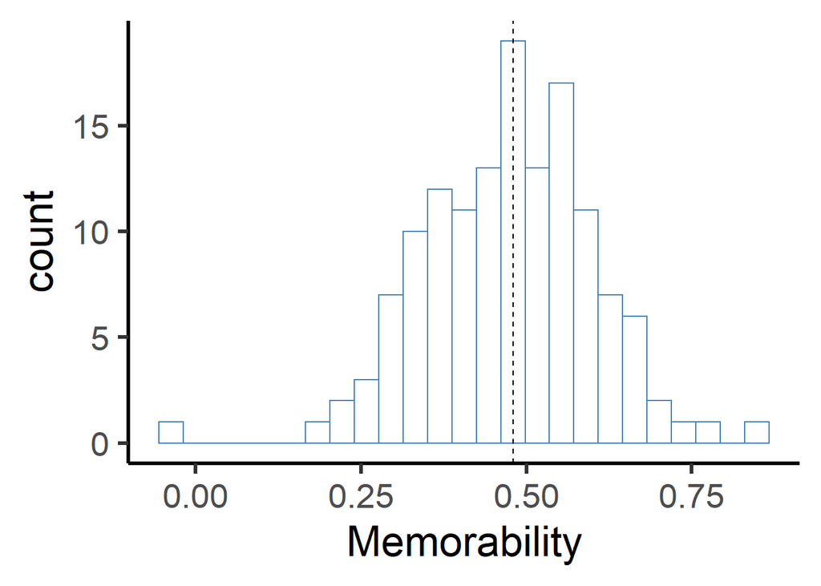

```r
##plot histogram for image memorability
hist.im = ggplot(img.values, aes(x=Memorability)) +
  geom_histogram(color="steelblue", fill="white", bins = 25) +
  geom_vline(xintercept = 0.48,linetype = "dashed") +
  theme_classic(base_size = 26)

hist.im
```

### Split-half consistency analysis (Figure 2B)

Calculated the split-half pearson correlation between the two groups with 1000 iterations.

The analysis code are saved in file **consistency_analysis.R**, but not evaluated in this rmd file for convenience. Only the plotted consistency figure is shown here.

```r
dat.mem = dat %>%  select(starts_with('Answer')) %>% dplyr::mutate(ID = row_number())
img.names = img.values %>% select(image)

#load and apply function for calculating split-half analysis
source("consistency_analysis.R", local = knitr::knit_global())

#plot the consistency figure
p.image.1000 = plot.data.ran %>% ggplot() +
  geom_line(aes(x = Rank, y = mean.x), colour="darkblue",size=1)+
  geom_line(aes(x = Rank, y = mean.y), colour="steelblue",size=1)+
  geom_line(aes(x = Rank, y = mean.ran), colour="grey",size=1)+
  ylab("Average across iterations") +
  theme_classic(base_size = 14)+
  labs(color = "Legend") +
  scale_color_manual(values = colors)

p.image.1000

#save image if needed
#ggsave('C:/Users/Christine/Box Sync/data/mem_dm_all_results/visualization/consistency_im.png', width = 8, height = 6, units = 'in')

#save the split-half groups if needed
#write.csv(mem.scores.1, "split-image-group-1.csv")
#write.csv(mem.scores.2, "split-image-group-2.csv")
#write.csv(corr, "split-image-corr.csv")
```

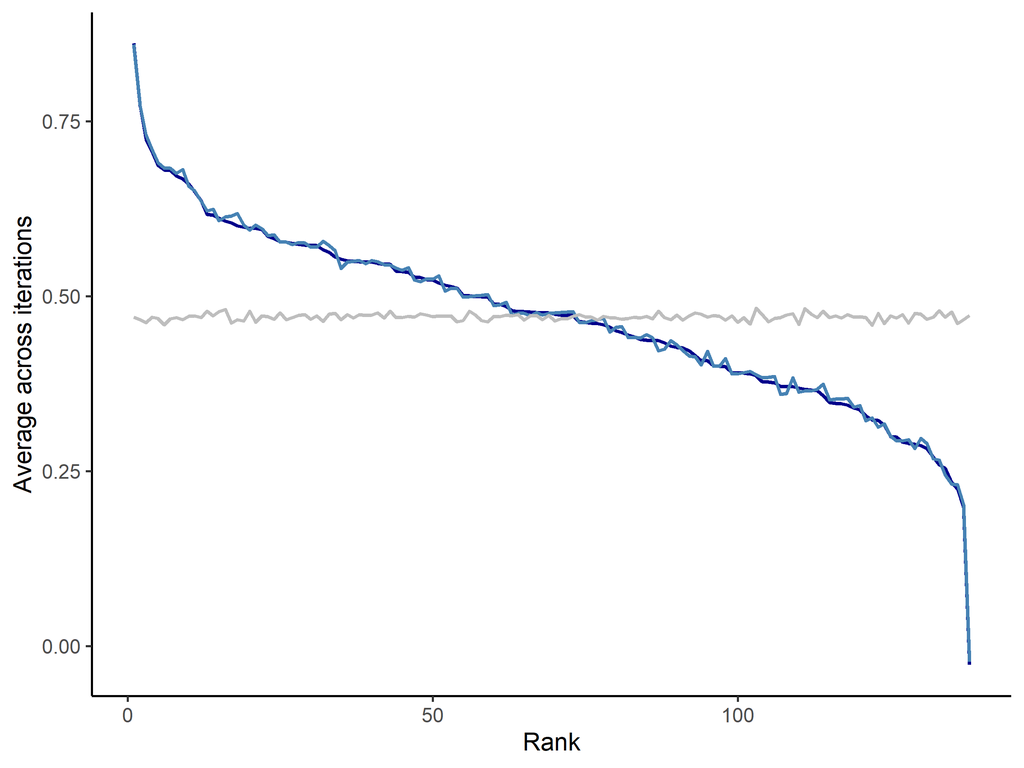

```r
knitr::include_graphics('C:/Users/Christine/Box Sync/data/mem_dm_all_results/visualization/consistency_im.png')
```

## Experiment 1B: Image Choice Task (N = 44)

### Data cleaning and pre-process

Load the cleaned choice task data from **Exp1B.csv**. The exclusion criteria are specified in the manuscript

```r
## Setup for exp2
#loading data files
dm.image = read.csv("C:/Users/Christine/Box Sync/data/mem_dm_share/Exp1B.csv")

#select choice trials and preprocess data
choice = dm.image %>% filter(ttype == 'choice_task')
choice = choice %>% filter(rt != "null") %>%
  mutate(rt = as.numeric(rt)) %>%
  mutate(delta.value = as.numeric(value_right) - as.numeric(value_left)) %>%
  mutate(delta.mem = as.numeric(mem_right) - as.numeric(mem_left)) %>%
  mutate(choseright = case_when(key_press == 75 ~ 1, key_press ==74 ~ 0)) %>%
  mutate(abs.mem = abs(delta.mem)) %>%
  mutate(chosehigh.mem = case_when(choseright == 1 & delta.mem >=0 ~ 1, choseright == 0 & delta.mem <0 ~ 1, choseright == 1 & delta.mem <0 ~ 0,choseright == 0 & delta.mem >=0 ~ 0 )) %>%
  dplyr::group_by(ID) %>% dplyr::mutate(z.delta.value = scale(delta.value))

choice = choice %>% filter(rt >= 300)

#select rating trials to get subjective values of images from each participant
rating = dm.image %>% filter(ttype == 'rating_task') %>%
  dplyr::group_by(ID) %>% mutate(z = scale(as.numeric(response)))

#calculate mean values for each stimuli
values = rating %>% dplyr::group_by(image) %>%
  dplyr::summarise(value = mean(as.numeric(response)))%>%
  mutate(item = substring(image, 54)) %>%
  dplyr::rename(url = image) %>%
  dplyr::rename(image = item)
#combine mean values with mem measures
mem = merge(select(values, -url), mem, by = "image", sort = TRUE)

#test correlation between memorability and averaged subjective values
cor.test(mem$Memorability, mem$value)
```

```
##
##  Pearson's product-moment correlation
##
## data:  mem$Memorability and mem$value
## t = 1.8119, df = 136, p-value = 0.07221
## alternative hypothesis: true correlation is not equal to 0
## 95 percent confidence interval:
##  -0.01393677  0.31261047
## sample estimates:
##       cor
## 0.1535256
```

z-scored image values for each participant, and calculated delta z-scored values for each choice trial

```r
## z-score values for each subject
#calculate z scores within each ID
rating.merge = rating[c('ID', 'z', 'image')]
rating.merge.l = rating.merge %>% dplyr::rename(stim_left = image)
rating.merge.r = rating.merge %>% dplyr::rename(stim_right = image)

#merge columns based on ID and stimuli names
choice.z = merge(rating.merge.l, choice, by = c('ID', 'stim_left')) %>%
  dplyr::rename(z.value.l = z)
choice.z = merge(rating.merge.r, choice.z, by = c('ID', 'stim_right')) %>%
  dplyr::rename(z.value.r = z)
choice.z = choice.z %>% mutate(z.delta.value = z.value.r - z.value.l)
#calculate abs z delta value
choice.z = choice.z %>% mutate(abs.delta.v.z = abs(z.delta.value),
                               chosehigh.value = case_when(choseright == 1 & delta.value >=0 ~ 1, choseright == 0 & delta.value <0 ~ 1, choseright == 1 & delta.value <0 ~ 0,choseright == 0 & delta.value >=0 ~ 0 ))
```

### Relationship between value and choice

Relationship between **choice preference** and **item value** for trials (N = 2939) that |Δmem| are close to 0.

```r
#filter data
# trials = 2939
choice.z = choice.z %>%
  arrange(ID, abs.mem) %>%
  group_by(ID) %>%
  dplyr::mutate(rank = 1:n()) %>%
  dplyr::mutate(median = median(rank)) %>%
  ungroup()
choice.low.m = choice.z %>% filter(rank <= median)

#generate the linear regression model
m.i.v = glmer(chosehigh.value~1+abs.delta.v.z+(1+abs.delta.v.z|ID),
           data = choice.low.m, family = "binomial",
           control=glmerControl(check.conv.singular = .makeCC(action = "ignore",  tol = 1e-4)))

#reporting stats
tidy(m.i.v,conf.int=TRUE,exponentiate=TRUE,effects="fixed")
```

```
## # A tibble: 2 x 8
##   effect term          estimate std.error statistic  p.value conf.low conf.high
##   <chr>  <chr>            <dbl>     <dbl>     <dbl>    <dbl>    <dbl>     <dbl>
## 1 fixed  (Intercept)      0.947    0.0493     -1.04 2.99e- 1    0.856      1.05
## 2 fixed  abs.delta.v.z    3.58     0.392      11.7  1.78e-31    2.89       4.44
```

Plot the predicted model and binned data (Figure 3A).

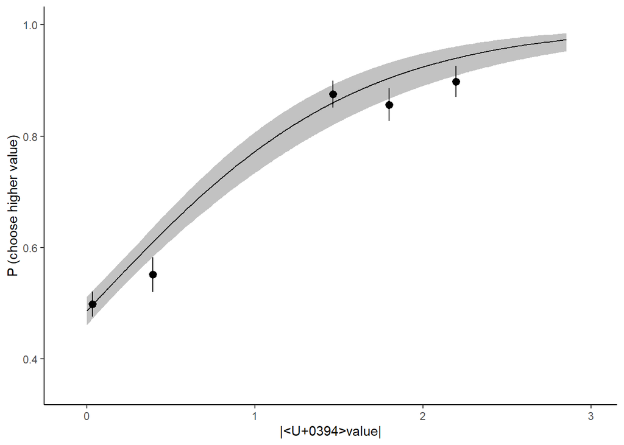

```r
p1 <- ggpredict(m.i.v, terms = "abs.delta.v.z [all]")

p <- ggplot(p1, aes(x = x, y = predicted)) + geom_line(show.legend = FALSE) +
  geom_ribbon(aes(ymin = p1$conf.low, ymax = p1$conf.high),alpha = 0.3, linetype =1, show.legend = FALSE) + theme_classic()

#calculate mean/sd for each actual data point - removing delta value = 0
choice.v.plt <- choice.low.m %>%
  filter(delta.value != 0) %>%
  #dplyr::group_by(ID) %>%
  mutate(bin.value=ntile(abs.delta.v.z, 5))
#for abs.delta.value
choice.plt.ppl = choice.v.plt %>% group_by(bin.value, ID) %>%
  summarise_at(vars(abs.delta.v.z, chosehigh.value), list(mean = mean))
choice.plt.df = choice.plt.ppl %>% group_by(bin.value) %>%
  summarise_at(vars(abs.delta.v.z_mean, chosehigh.value_mean), list(mean = mean, sd = sd))

# calculate the lower and upper limits based on 1 standard error from the mean - divide sd by sqrt of 44 (number of subjs in each quintile)
choice.plt.df$lowSE <- choice.plt.df$chosehigh.value_mean_mean - (choice.plt.df$chosehigh.value_mean_sd)/sqrt(44)
choice.plt.df$highSE <- choice.plt.df$chosehigh.value_mean_mean + (choice.plt.df$chosehigh.value_mean_sd)/sqrt(44)

p = p +
  geom_pointrange(data = choice.plt.df, aes(x = abs.delta.v.z_mean_mean, y = chosehigh.value_mean_mean, ymin = lowSE, ymax = highSE), show.legend = FALSE)+
  xlab("|Δvalue|") +
  ylab("P (choose higher value)") + xlim(-0.1, 3) + ylim(0.35,1)

p
```

Relationship between **RT** and **item value** for trials (N = 2939) that |Δmem| are close to 0.

```r
#lmer model for predicting logged RT based on |Δvalue|
m3.value.log = lmer(log(rt) ~ abs.delta.v.z + (abs.delta.v.z|ID),
           data = choice.low.m,
           control=lmerControl(check.conv.singular = .makeCC(action = "ignore",  tol = 1e-4)))

# calculate coefficient for RT model
confint(m3.value.log,method="Wald")
```

```
##                     2.5 %      97.5 %
## .sig01                 NA          NA
## .sig02                 NA          NA
## .sig03                 NA          NA
## .sigma                 NA          NA
## (Intercept)    6.97863094  7.11902675
## abs.delta.v.z -0.05981488 -0.02414781
```

```r
# use normal distribution to approximate p-value
coefs <- data.frame(coef(summary(m3.value.log)))
coefs$p.z <- 2 * (1 - pnorm(abs(coefs$t.value)))
print(paste0('The estimate for |Δvalue| is ', coefs$Estimate[2], ' (p = ', coefs$p.z[2],')' ))
```

```
## [1] "The estimate for |Δvalue| is -0.041981346514297 (p = 3.95207402825726e-06)"
```

Plot the predicted model and data (Figure 3B).

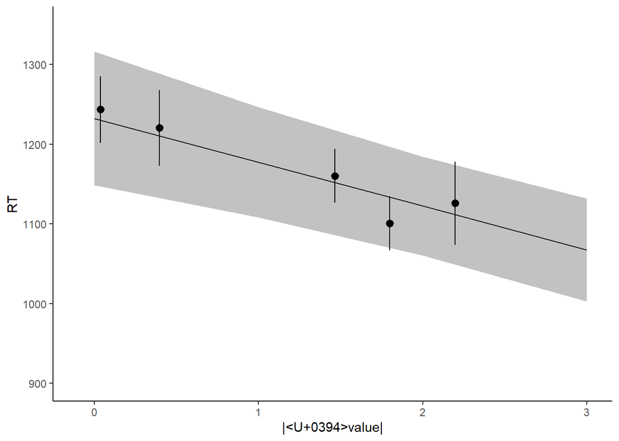

```r
m3.value = lmer(rt ~ abs.delta.v.z + (abs.delta.v.z|ID),
           data = choice.low.m)

#plot data
p3 <- ggpredict(m3.value, terms = "abs.delta.v.z")

p.rt.v <- ggplot(p3, aes(x = x, y = predicted)) + geom_line(show.legend = FALSE) +
  geom_ribbon(aes(ymin = p3$conf.low, ymax = p3$conf.high),alpha = 0.3, linetype =1, show.legend = FALSE) + theme_classic() + xlim(0,3)

#calculate mean/sd for each actual data point
#for abs.delta.value
choice.plt.ppl = choice.v.plt %>% group_by(bin.value, ID) %>%
  summarise_at(vars(abs.delta.v.z, chosehigh.value, rt), list(mean = mean))
choice.plt.df = choice.plt.ppl %>% group_by(bin.value) %>%
  summarise_at(vars(abs.delta.v.z_mean, chosehigh.value_mean, rt_mean), list(mean=mean, sd = sd))

# calculate the lower and upper limits based on 1 standard error from the mean - divide sd by sqrt of 44 (number of subjs in each quintile)
choice.plt.df$lowSE <- choice.plt.df$rt_mean_mean - (choice.plt.df$rt_mean_sd)/sqrt(44)
choice.plt.df$highSE <- choice.plt.df$rt_mean_mean + (choice.plt.df$rt_mean_sd)/sqrt(44)

p.rt.v.data = p.rt.v + geom_pointrange(data = choice.plt.df, aes(x = abs.delta.v.z_mean_mean, y = rt_mean_mean, ymin = lowSE, ymax = highSE), show.legend = FALSE) +
  xlab("|Δvalue|") + ylab("RT") +
  xlim(-0.1,3)+ylim(900, 1350)
p.rt.v.data
```

### Relationship between memorability and choice

Relationship between **choice preference** and **item memorability** for trials (N = 2939) that |Δvalue| are close to 0.

```r
## filter data into trials that delta value close to 0
#split trials into high/low delta mem based on within-subject median
# trials = 2939
choice.z = choice.z %>%
  arrange(ID, abs.delta.v.z) %>%
  group_by(ID) %>%
  dplyr::mutate(rank.v = 1:n()) %>%
  dplyr::mutate(median.v = median(rank.v)) %>%
  ungroup()
choice.low.v = choice.z %>% filter(rank.v <= median.v)

# generate the model choice preference ~ |Δmem|
m.i.m = glmer(chosehigh.mem~1+abs.mem+(1+abs.mem|ID),
           data = choice.low.v, family = "binomial",
           control=glmerControl(check.conv.singular = .makeCC(action = "ignore",  tol = 1e-4)))

#calculate coefficient
tidy(m.i.m,conf.int=TRUE,exponentiate=TRUE,effects="fixed")
```

```
## # A tibble: 2 x 8
##   effect term        estimate std.error statistic p.value conf.low conf.high
##   <chr>  <chr>          <dbl>     <dbl>     <dbl>   <dbl>    <dbl>     <dbl>
## 1 fixed  (Intercept)    1.02     0.0608     0.356   0.722    0.909      1.15
## 2 fixed  abs.mem        0.786    0.260     -0.730   0.465    0.411      1.50
```

Plot the predicted model and binned data for memorability and choice (Figure 3C).

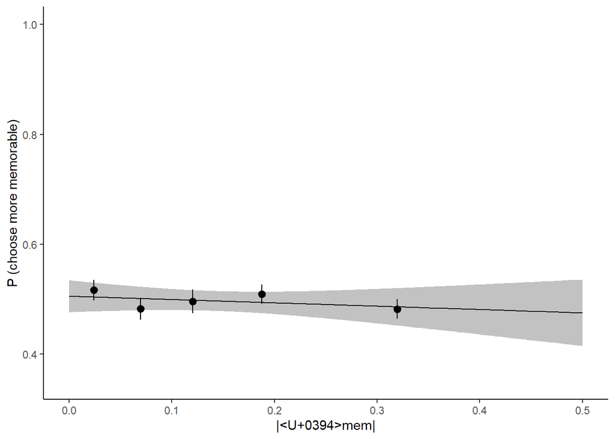

```r
p2 <- ggpredict(m.i.m, terms = "abs.mem [all]")

p.mem.choice <- ggplot(p2, aes(x = x, y = predicted)) + geom_line(show.legend = FALSE) +
  geom_ribbon(aes(ymin = p2$conf.low, ymax = p2$conf.high),alpha = 0.3, linetype =1, show.legend = FALSE) + theme_classic()

p.mem.choice = p.mem.choice +
  xlab("Delta Memorability") +
  scale_y_continuous(limits = c(0.35,1))

#calculate mean/sd for each actual data point
choice.m.plt <- choice.low.v %>%
  dplyr::group_by(ID) %>%
  mutate(bin.mem=ntile(abs.mem, 5))
#for abs.delta.value
choice.plt.mem.ppl = choice.m.plt %>% group_by(bin.mem, ID) %>%
  summarise_at(vars(abs.mem, chosehigh.mem, rt), list(mean = mean))
choice.plt.mem.df = choice.plt.mem.ppl %>% group_by(bin.mem) %>%
  summarize_at(vars(abs.mem_mean, chosehigh.mem_mean, rt_mean), list(mean=mean, sd = sd))

# calculate the lower and upper limits based on 1 standard error from the mean - divide sd by sqrt of 44 (number of subjs in each quintile)
choice.plt.mem.df$lowSE <- choice.plt.mem.df$chosehigh.mem_mean_mean - (choice.plt.mem.df$chosehigh.mem_mean_sd)/sqrt(44)
choice.plt.mem.df$highSE <- choice.plt.mem.df$chosehigh.mem_mean_mean + (choice.plt.mem.df$chosehigh.mem_mean_sd)/sqrt(44)

p.mem.choice = p.mem.choice + geom_pointrange(data = choice.plt.mem.df, aes(x = abs.mem_mean_mean, y = chosehigh.mem_mean_mean, ymin = lowSE, ymax = highSE), show.legend = FALSE) +
  xlab("|Δmem|") + ylab("P (choose more memorable)")+ xlim(0,0.5)

p.mem.choice
```

Relationship between **RT** and **item memorability** for trials (N = 2939) that |Δvalue| are close to 0.

```r
#lmer model for RT ~ memorability
m4.value.log = lmer(log(rt) ~ abs.mem + (abs.mem|ID),
           data = choice.m.plt,
           control=lmerControl(check.conv.singular = .makeCC(action = "ignore",  tol = 1e-4)))
# calculate coefficient for RT model
confint(m4.value.log,method="Wald")
```

```
##                  2.5 %     97.5 %
## .sig01              NA         NA
## .sig02              NA         NA
## .sig03              NA         NA
## .sigma              NA         NA
## (Intercept)  6.9774324 7.11738190
## abs.mem     -0.1259698 0.06220623
```

```r
coefs <- data.frame(coef(summary(m4.value.log)))
# use normal distribution to approximate p-value
coefs$p.z <- 2 * (1 - pnorm(abs(coefs$t.value)))
print(paste0('The estimate for |Δmem| is ', coefs$Estimate[2], ' (p = ', coefs$p.z[2],')' ))
```

```
## [1] "The estimate for |Δmem| is -0.0318818015643488 (p = 0.506603706430425)"
```

Plot the predicted model and binned data for memorability and RT (Figure 3D).

```r
m4.value = lmer(rt ~ abs.mem + (abs.mem|ID),
           data = choice.m.plt)
```

```
## boundary (singular) fit: see ?isSingular
```

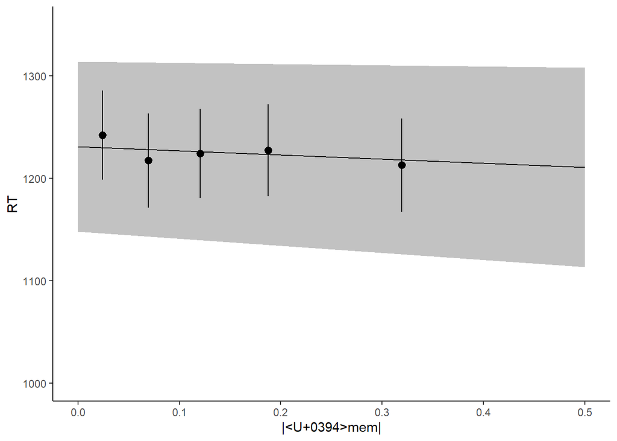

```r
p4 <- ggpredict(m4.value, terms = "abs.mem")

p.mem.rt <- ggplot(p4, aes(x = x, y = predicted)) + geom_line(show.legend = FALSE) +
  geom_ribbon(aes(ymin = p4$conf.low, ymax = p4$conf.high),alpha = 0.3, linetype =1, show.legend = FALSE) + theme_classic()

# calculate the lower and upper limits based on 1 standard error from the mean - divide sd by sqrt of 44 (number of subjs in each quintile)
choice.plt.mem.df$lowSE <- choice.plt.mem.df$rt_mean_mean - (choice.plt.mem.df$rt_mean_sd)/sqrt(44)
choice.plt.mem.df$highSE <- choice.plt.mem.df$rt_mean_mean + (choice.plt.mem.df$rt_mean_sd)/sqrt(44)

p.mem.rt = p.mem.rt + geom_pointrange(data = choice.plt.mem.df, aes(x = abs.mem_mean_mean, y = rt_mean_mean, ymin = lowSE, ymax = highSE), show.legend = FALSE) +
  xlab("|Δmem|") + ylab("RT") + xlim(0,0.5)+ylim(1000, 1350)

p.mem.rt
```

## Experiment 2A: representativeness task (N = 40)

Calculate the mean representativeness for each image-word pairs, and tested if it is correlated with image/word memorability.

```r
#load data for Exp2A (representativeness task)
dat = read.csv("C:/Users/Christine/Box Sync/data/mem_dm_share/Exp2A.csv")

#calculate average z-scored rep data for each image/word pairs
rep = dat %>% filter(ttype == "rep_rating")
rep = rep %>% dplyr::group_by(run_id) %>% dplyr::mutate(z.score = scale(as.numeric(response)))
rep.mean = rep %>% dplyr::group_by(word) %>%
  dplyr::summarize(rep = mean(as.numeric(response)), rep.z = mean(z.score), n = n()) %>%
  select(-n)
mem = merge(rep.mean, mem, by.x = "word", by.y = "food.item")
```

Positive correlation between representative measurement and image values

```r
cor.test(mem$rep.z, mem$value)
```

```
##
##  Pearson's product-moment correlation
##
## data:  mem$rep.z and mem$value
## t = 2.1503, df = 136, p-value = 0.0333
## alternative hypothesis: true correlation is not equal to 0
## 95 percent confidence interval:
##  0.01467342 0.33819070
## sample estimates:
##       cor
## 0.1813336
```

No correlation with image memorability

```r
cor.test(mem$rep.z, mem$Memorability)
```

```
##
##  Pearson's product-moment correlation
##
## data:  mem$rep.z and mem$Memorability
## t = 0.9629, df = 136, p-value = 0.3373
## alternative hypothesis: true correlation is not equal to 0
## 95 percent confidence interval:
##  -0.0859997  0.2460097
## sample estimates:
##        cor
## 0.08228769
```

## Experiment 2B: word memorability (N = 195)

Load the cleaned data from **Exp2B.csv**, and applied function to calculate the memorability score of word for food items.

```r
#Load memorability data
dat.w = read.csv("C:/Users/Christine/Box Sync/data/mem_dm_share/Exp2B.csv")

#apply function for calculating memorability scores
img.values.w = calculate_mem(dat.w) %>% dplyr::rename(word.mem = Memorability)

#summarize data and combine it with image/word indexes
summary(img.values.w)
```

```
##   Target.count     Hit.count        FA.count           HR
##  Min.   :37.00   Min.   :14.00   Min.   : 4.00   Min.   :0.3500
##  1st Qu.:40.00   1st Qu.:21.00   1st Qu.:11.00   1st Qu.:0.5128
##  Median :41.00   Median :24.00   Median :13.00   Median :0.5854
##  Mean   :40.98   Mean   :23.88   Mean   :13.14   Mean   :0.5824
##  3rd Qu.:42.00   3rd Qu.:27.00   3rd Qu.:15.00   3rd Qu.:0.6500
##  Max.   :46.00   Max.   :34.00   Max.   :24.00   Max.   :0.8095
##       FAR             word.mem          image
##  Min.   :0.09756   Min.   :-0.0250   Length:138
##  1st Qu.:0.25641   1st Qu.: 0.1795   Class :character
##  Median :0.32500   Median : 0.2532   Mode  :character
##  Mean   :0.32105   Mean   : 0.2614
##  3rd Qu.:0.38221   3rd Qu.: 0.3418
##  Max.   :0.60000   Max.   : 0.5854
```

```r
mem = merge(img.values.w, mem, by.x = "image", by.y = "word")
```

No correlation between image and word memorability.

```r
cor.test(mem$Memorability, mem$word.mem)
```

```
##
##  Pearson's product-moment correlation
##
## data:  mem$Memorability and mem$word.mem
## t = 1.7047, df = 136, p-value = 0.09054
## alternative hypothesis: true correlation is not equal to 0
## 95 percent confidence interval:
##  -0.02302475  0.30438461
## sample estimates:
##       cor
## 0.1446366
```

No correlation between word memorability and representativness of word/image pairs

```r
cor.test(mem$word.mem, mem$rep.z)
```

```
##
##  Pearson's product-moment correlation
##
## data:  mem$word.mem and mem$rep.z
## t = 0.45076, df = 136, p-value = 0.6529
## alternative hypothesis: true correlation is not equal to 0
## 95 percent confidence interval:
##  -0.129316  0.204409
## sample estimates:
##        cor
## 0.03862342
```

### Distribution of word memorability (Figure 5A)

The lowest one is **skittles**, and the highest one is **kit kat**

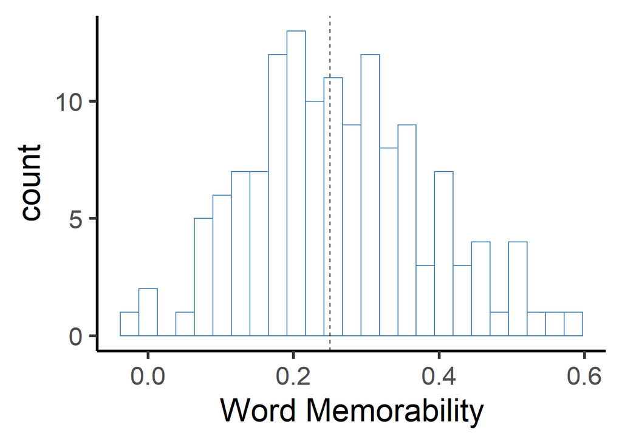

```r
## ggplot histogram
hist.mem.word = ggplot(mem, aes(x=word.mem)) +
  geom_histogram(color="steelblue", fill="white", bins = 25) +
  geom_vline(xintercept = 0.25,linetype = "dashed") +
  theme_classic(base_size = 26)+xlab("Word Memorability")

hist.mem.word
```

```r
ggsave('C:/Users/Christine/Box Sync/data/mem_dm_all_results/visualization/hist_word.png', width = 8, height = 6, units = 'in')
```

### Split-half consistency analysis (Figure 5B)

Same as Exp1A, we calculated the split-half pearson correlation between the two groups with 1000 iterations.

The analysis code are saved in file **consistency_analysis.R**, but not evaluated in this rmd file for convenience. Only the plotted consistency figure is shown here.

```r
dat.mem = dat.w %>%  select(starts_with('Answer')) %>% dplyr::mutate(ID = row_number())
img.names = img.values.w %>% select(image)

#load and apply function again for calculating split-half analysis
source("consistency_analysis.R", local = knitr::knit_global())

#plot the consistency figure
p.image.1000.w = plot.data.ran %>% ggplot() +
  geom_line(aes(x = Rank, y = mean.x), colour="darkblue",size=1)+
  geom_line(aes(x = Rank, y = mean.y), colour="steelblue",size=1)+
  geom_line(aes(x = Rank, y = mean.ran), colour="grey",size=1)+
  ylab("Average across iterations") +
  theme_classic(base_size = 14)+
  labs(color = "Legend") +
  scale_color_manual(values = colors)

p.image.1000.w

#save image
#ggsave('C:/Users/Christine/Box Sync/data/mem_dm_all_results/visualization/consistency_im.png', width = 8, height = 6, units = 'in')

#save the split-half groups if needed
#write.csv(mem.scores.1, "split-word-group-1.csv")
#write.csv(mem.scores.2, "split-word-group-2.csv")
#write.csv(corr, "split-word-corr.csv")
```

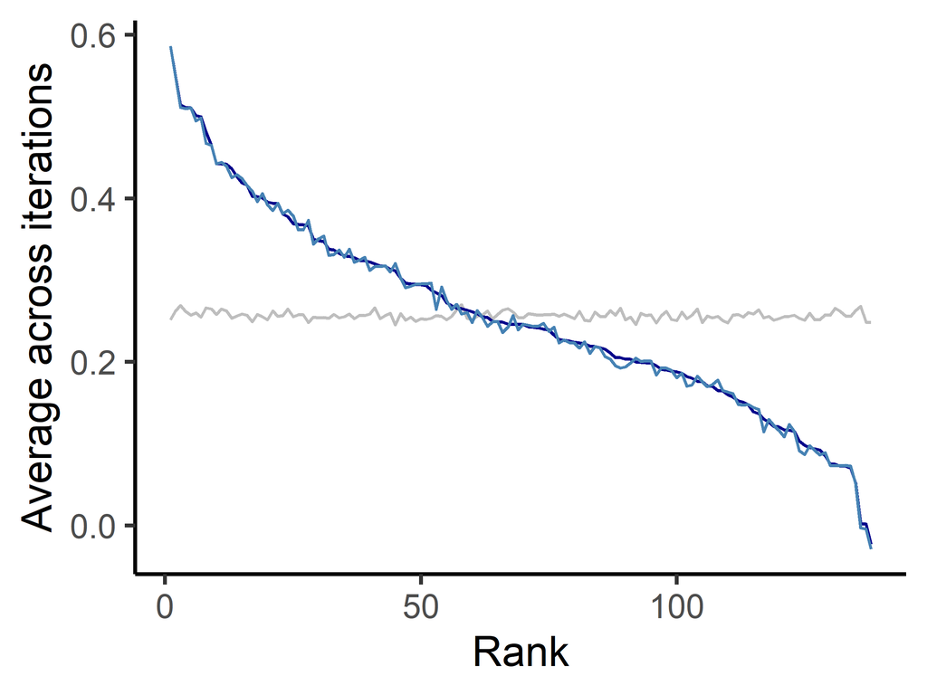

```r
knitr::include_graphics('C:/Users/Christine/Box Sync/data/mem_dm_all_results/visualization/consistency_word_1000.png')
```

## Experiment 2C: word choices (N = 45)

### Relationship between word value and choice

Load data file from **Exp2C.csv** and preprocess the data.

```r
## Setup for exp2C
#loading data files
dm.word = read.csv("C:/Users/Christine/Box Sync/data/mem_dm_share/Exp2C.csv")

#select choice trials and preprocess data
choice.w = dm.word %>% filter(ttype == 'choice_task')
choice.w = choice.w %>% filter(rt != "null", rt != 0) %>%
  mutate(rt = as.numeric(rt)) %>%
  mutate(delta.value = as.numeric(value_right) - as.numeric(value_left)) %>%
  mutate(choseright = case_when(response == 'k' ~ 1, response =='j' ~ 0)) %>%
  dplyr::group_by(ID) %>% dplyr::mutate(z.delta.value = scale(delta.value)) %>%
  mutate(abs.delta.v.z = abs(z.delta.value),
         chosehigh.value = case_when(choseright == 1 & delta.value >=0 ~ 1, choseright == 0 & delta.value <0 ~ 1, choseright == 1 & delta.value <0 ~ 0,choseright == 0 & delta.value >=0 ~ 0 ))

#exclude trails that have RT lower than 300
choice.w = choice.w %>% filter(rt >= 300)

#select rating trials to get subjective values of images from each participant
rating.w = dm.word %>% filter(ttype == 'rating_task') %>%
  dplyr::group_by(ID) %>% mutate(z = scale(as.numeric(response)))

#calculate mean values for each stimuli
values.word = rating.w %>% dplyr::group_by(word) %>%
  dplyr::summarise(word.value = mean(as.numeric(response)))
#combine mean values with mem measures
mem = merge(values.word, mem, by.x = "word", by.y = "image", sort = TRUE)
```

z-scored word values for each participant, and calculated delta z-scored values for each choice trial

```r
#merge word memorability based on words and stimuli position
word.mem = select(mem, word.mem, word)
choice.test = merge(word.mem, choice.w, by.x = 'word', by.y = 'stim_left') %>%
  dplyr::rename(stim_left = word, mem.l = word.mem)
choice.test = merge(word.mem, choice.test, by.x = 'word', by.y = 'stim_right') %>%
  dplyr::rename(stim_right = word, mem.r = word.mem)

choice.test = choice.test %>% mutate(delta.mem = as.numeric(mem.r) - as.numeric(mem.l)) %>%
  mutate(abs.mem = abs(delta.mem)) %>%
  mutate(chosehigh.mem = case_when(choseright == 1 & delta.mem >=0 ~ 1, choseright == 0 & delta.mem <0 ~ 1, choseright == 1 & delta.mem <0 ~ 0,choseright == 0 & delta.mem >=0 ~ 0 ))
```

### Relationship between word value and choice

Relationship between **choice preference** and **word value** for trials (N = 3080) that |Δmem_word| are close to 0.

```r
# select trials that |Δmem_word| are close to 0
# trials = 3080
choice.test = choice.test %>%
  arrange(ID, abs.mem) %>%
  group_by(ID) %>%
  dplyr::mutate(rank = 1:n()) %>%
  dplyr::mutate(median = median(rank)) %>%
  ungroup()
choice.low.m.w = choice.test %>% filter(rank <= median)

#generate the model
m.w.v = glmer(chosehigh.value~1+abs.delta.v.z+(1+abs.delta.v.z|ID),
           data = choice.low.m.w, family = "binomial",
           glmerControl(optimizer = "bobyqa", optCtrl = list(maxfun = 10000000)))

tidy(m.w.v,conf.int=TRUE,exponentiate=TRUE,effects="fixed")
```

```
## # A tibble: 2 x 8
##   effect term          estimate std.error statistic  p.value conf.low conf.high
##   <chr>  <chr>            <dbl>     <dbl>     <dbl>    <dbl>    <dbl>     <dbl>
## 1 fixed  (Intercept)      0.862    0.0463     -2.76 5.72e- 3    0.776     0.958
## 2 fixed  abs.delta.v.z    6.56     0.873      14.1  2.79e-45    5.05      8.51
```

Plot the predicted model and binned data for word value and choices (Figure 6A).

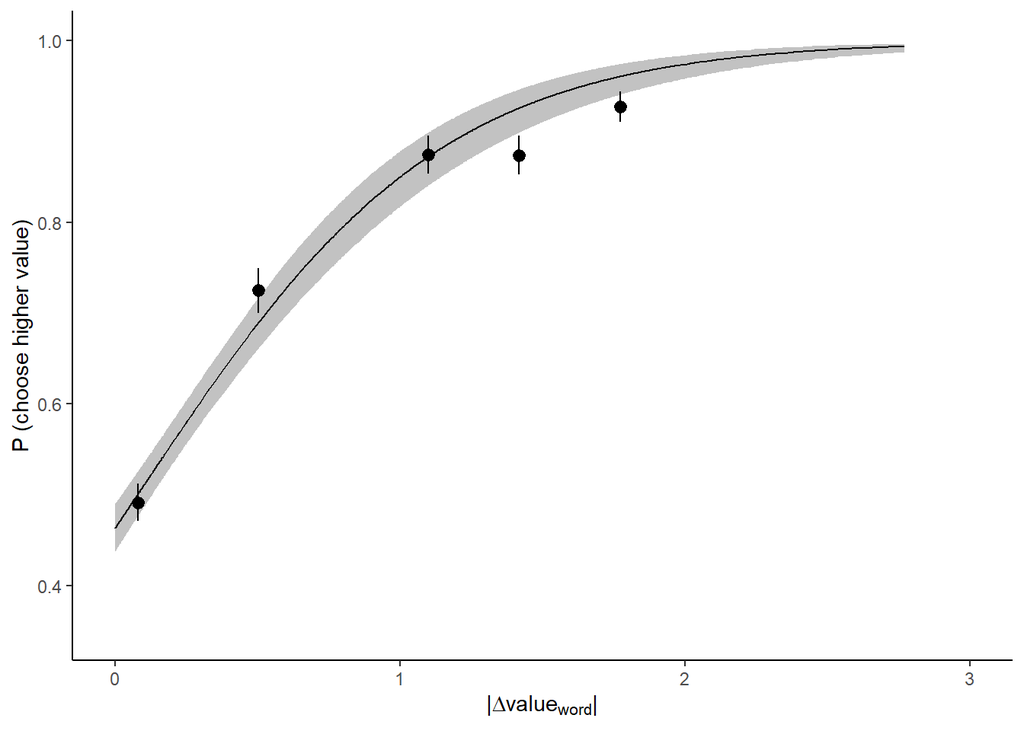

```r
p1.w <- ggpredict(m.w.v, terms = "abs.delta.v.z [all]")

p.w <- ggplot(p1.w, aes(x = x, y = predicted)) + geom_line(show.legend = FALSE) +
  geom_ribbon(aes(ymin = p1.w$conf.low, ymax = p1.w$conf.high),alpha = 0.3, linetype =1, show.legend = FALSE) + theme_classic() + ylim(0.35, 1.0) + xlim(0,3)

#calculate mean/sd for each actual data point
choice.v.plt <- choice.low.m.w %>%
  filter(delta.value != 0) %>%
  dplyr::group_by(ID) %>%
  mutate(bin.value=ntile(abs.delta.v.z, 5))

#for abs.delta.value
choice.plt.ppl = choice.v.plt %>% group_by(bin.value, ID) %>%
  summarise_at(vars(abs.delta.v.z, chosehigh.value), list(mean = mean))
choice.plt.df = choice.plt.ppl %>% group_by(bin.value) %>%
  summarise_at(vars(abs.delta.v.z_mean, chosehigh.value_mean), list(mean = mean, sd = sd))

# calculate the lower and upper limits based on 1 standard error from the mean - divide sd by sqrt of 45 (number of subjs in each quintile)
choice.plt.df$lowSE <- choice.plt.df$chosehigh.value_mean_mean - (choice.plt.df$chosehigh.value_mean_sd)/sqrt(45)
choice.plt.df$highSE <- choice.plt.df$chosehigh.value_mean_mean + (choice.plt.df$chosehigh.value_mean_sd)/sqrt(45)

p.w = p.w + geom_pointrange(data = choice.plt.df, aes(x = abs.delta.v.z_mean_mean, y = chosehigh.value_mean_mean, ymin = lowSE, ymax = highSE), show.legend = FALSE)+ xlab(expression(paste("|",Delta*value[word], "|"))) + ylab("P (choose higher value)")

p.w
```

Relationship between **RT** and **word value** for trials (N = 3080) that |Δmem_word| are close to 0.

```r
# generate the RT ~ value model
m3.word.log = lmer(log(rt) ~ abs.delta.v.z + (abs.delta.v.z|ID),
           data = choice.low.m.w)

# calculate coefficient for RT model
confint(m3.word.log,method="Wald")
```

```
##                     2.5 %      97.5 %
## .sig01                 NA          NA
## .sig02                 NA          NA
## .sig03                 NA          NA
## .sigma                 NA          NA
## (Intercept)    7.11649232  7.21538035
## abs.delta.v.z -0.08138338 -0.04552402
```

```r
# use normal distribution to approximate p-value
coefs <- data.frame(coef(summary(m3.word.log)))
coefs$p.z <- 2 * (1 - pnorm(abs(coefs$t.value)))

print(paste0('The estimate for |Δvalue_word| is ', coefs$Estimate[2], ' (p = ', coefs$p.z[2],')' ))
```

```
## [1] "The estimate for |Δvalue_word| is -0.0634536997362722 (p = 4.02300415203172e-12)"
```

Plot the predicted model and binned data for word value and RT (Figure 6B).

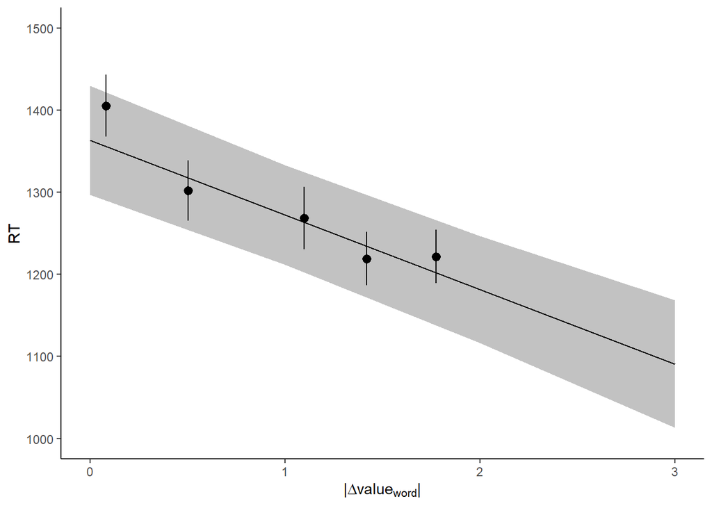

```r
m3.word = lmer(rt ~ abs.delta.v.z + (abs.delta.v.z|ID),
           data = choice.low.m.w)


p3 <- ggpredict(m3.word, terms = "abs.delta.v.z")

p.rt.w.v <- ggplot(p3, aes(x = x, y = predicted)) + geom_line(show.legend = FALSE) +
  geom_ribbon(aes(ymin = p3$conf.low, ymax = p3$conf.high),alpha = 0.3, linetype =1, show.legend = FALSE) + theme_classic() + xlim(0,3) + ylim(1000, 1500)

#calculate mean/sd for each actual data point
#for abs.delta.value
choice.plt.ppl = choice.v.plt %>% group_by(bin.value, ID) %>%
  summarise_at(vars(abs.delta.v.z, chosehigh.value, rt), list(mean = mean))
choice.plt.df = choice.plt.ppl %>% group_by(bin.value) %>%
  summarise_at(vars(abs.delta.v.z_mean, chosehigh.value_mean, rt_mean), list(mean=mean, sd = sd))

# calculate the lower and upper limits based on 1 standard error from the mean - divide sd by sqrt of 45 (approx number of subjs in each quintile)
choice.plt.df$lowSE <- choice.plt.df$rt_mean_mean - (choice.plt.df$rt_mean_sd)/sqrt(45)
choice.plt.df$highSE <- choice.plt.df$rt_mean_mean + (choice.plt.df$rt_mean_sd)/sqrt(45)

p.rt.w.v = p.rt.w.v + geom_pointrange(data = choice.plt.df, aes(x = abs.delta.v.z_mean_mean, y = rt_mean_mean, ymin = lowSE, ymax = highSE), show.legend = FALSE) +
  xlab(expression(paste("|",Delta*value[word], "|"))) + ylab("RT")

p.rt.w.v
```

### Relationship between word memorability and chocie

Relationship between **choice preference** and **word memorability** for trials (N = 3080) that |Δvalue_word| are close to 0.

```r
## filter data into trials that delta value close to 0
#split trials into high/low delta mem based on within-subject median
choice.test = choice.test %>%
  arrange(ID, abs.delta.v.z) %>%
  group_by(ID) %>%
  dplyr::mutate(rank.v = 1:n()) %>%
  dplyr::mutate(median.v = median(rank.v)) %>%
  ungroup()
choice.low.v.w = choice.test %>% filter(rank.v <= median.v)

# generate the model
m.w.m = glmer(chosehigh.mem~1+abs.mem+(1+abs.mem|ID),
           data = choice.low.v.w, family = "binomial",
           control=glmerControl(check.conv.singular = .makeCC(action = "ignore",  tol = 1e-4)))
tidy(m.w.m,conf.int=TRUE,exponentiate=TRUE,effects="fixed")
```

```
## # A tibble: 2 x 8
##   effect term        estimate std.error statistic p.value conf.low conf.high
##   <chr>  <chr>          <dbl>     <dbl>     <dbl>   <dbl>    <dbl>     <dbl>
## 1 fixed  (Intercept)    0.988    0.0604    -0.199   0.842    0.876      1.11
## 2 fixed  abs.mem        1.10     0.388      0.272   0.786    0.552      2.20
```

Plot the predicted model and binned data for word memorability and choice (Figure 6C).

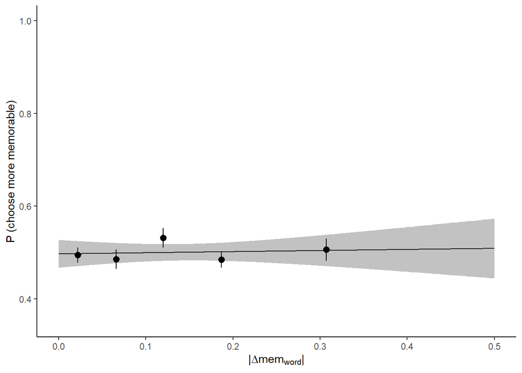

```r
p2.w <- ggpredict(m.w.m, terms = "abs.mem [all]")

p.mem.w.choice <- ggplot(p2.w, aes(x = x, y = predicted)) + geom_line(show.legend = FALSE) +
  geom_ribbon(aes(ymin = p2.w$conf.low, ymax = p2.w$conf.high),alpha = 0.3, linetype =1, show.legend = FALSE) + theme_classic()

p.mem.w.choice = p.mem.w.choice +
  xlab("Delta Memorability") +
  scale_y_continuous(limits = c(0.35,1))

#calculate mean/sd for each actual data point
choice.m.plt <- choice.low.v.w %>%
  dplyr::group_by(ID) %>%
  mutate(bin.mem=ntile(abs.mem, 5))
#for abs.delta.value
choice.plt.mem.ppl = choice.m.plt %>% group_by(bin.mem, ID) %>%
  summarise_at(vars(abs.mem, chosehigh.mem, rt), list(mean = mean))
choice.plt.mem.df = choice.plt.mem.ppl %>% group_by(bin.mem) %>%
  summarize_at(vars(abs.mem_mean, chosehigh.mem_mean, rt_mean), list(mean=mean, sd = sd))

# calculate the lower and upper limits based on 1 standard error from the mean - divide sd by sqrt of 45 (number of subjs in each quintile)
choice.plt.mem.df$lowSE <- choice.plt.mem.df$chosehigh.mem_mean_mean - (choice.plt.mem.df$chosehigh.mem_mean_sd)/sqrt(45)
choice.plt.mem.df$highSE <- choice.plt.mem.df$chosehigh.mem_mean_mean + (choice.plt.mem.df$chosehigh.mem_mean_sd)/sqrt(45)

p.mem.w.choice = p.mem.w.choice + geom_pointrange(data = choice.plt.mem.df, aes(x = abs.mem_mean_mean, y = chosehigh.mem_mean_mean, ymin = lowSE, ymax = highSE), show.legend = FALSE) +
  xlab(expression(paste("|",Delta*mem[word], "|"))) + ylab("P (choose more memorable)") + xlim(0,0.5)

p.mem.w.choice
```

Relationship between **RT** and **word memorability** for trials (N = 3080) that |Δvalue_word| are close to 0.

```r
#fit the model for RT ~ word.mem
m4.value.w.log = lmer(log(rt) ~ abs.mem + (abs.mem|ID),
           data = choice.low.v.w,
           control=lmerControl(check.conv.singular = .makeCC(action = "ignore",  tol = 1e-4)))

# calculate coefficient for RT model
confint(m4.value.w.log,method="Wald")
```

```
##                  2.5 %     97.5 %
## .sig01              NA         NA
## .sig02              NA         NA
## .sig03              NA         NA
## .sigma              NA         NA
## (Intercept)  7.1070251 7.20663723
## abs.mem     -0.1318111 0.05916217
```

```r
coefs <- data.frame(coef(summary(m4.value.w.log)))
# use normal distribution to approximate p-value
coefs$p.z <- 2 * (1 - pnorm(abs(coefs$t.value)))

print(paste0('The estimate for |Δvalue_word| is ', coefs$Estimate[2], ' (p = ', coefs$p.z[2],')' ))
```

```
## [1] "The estimate for |Δvalue_word| is -0.0363244815544027 (p = 0.455910148406684)"
```

Plot the predicted model and binned data for word memorability and RT (Figure 6D).

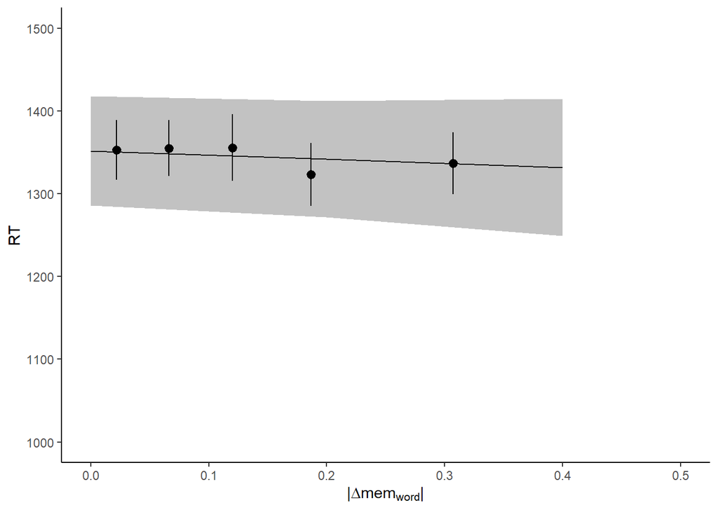

```r
#generate predict model for plotting
m4.value.w = lmer(rt ~ abs.mem + (abs.mem|ID),
           data = choice.low.v.w,
           control=lmerControl(check.conv.singular = .makeCC(action = "ignore",  tol = 1e-4)))
#plot
p4.w <- ggpredict(m4.value.w, terms = "abs.mem")

p.mem.w.rt <- ggplot(p4.w, aes(x = x, y = predicted)) + geom_line(show.legend = FALSE) +
  geom_ribbon(aes(ymin = p4.w$conf.low, ymax = p4.w$conf.high),alpha = 0.3, linetype =1, show.legend = FALSE) + theme_classic()

# calculate the lower and upper limits based on 1 standard error from the mean - divide sd by sqrt of 45 (approx number of subjs in each quintile)
choice.plt.mem.df$lowSE <- choice.plt.mem.df$rt_mean_mean - (choice.plt.mem.df$rt_mean_sd)/sqrt(45)
choice.plt.mem.df$highSE <- choice.plt.mem.df$rt_mean_mean + (choice.plt.mem.df$rt_mean_sd)/sqrt(45)

p.mem.w.rt = p.mem.w.rt + geom_pointrange(data = choice.plt.mem.df, aes(x = abs.mem_mean_mean, y = rt_mean_mean, ymin = lowSE, ymax = highSE), show.legend = FALSE) +
  xlab(expression(paste("|",Delta*mem[word], "|"))) + ylab("RT") + xlim(0,0.5) + ylim(1000, 1500)

p.mem.w.rt
```

## Supplement

### Variance of delta image memorability (Figure S1)

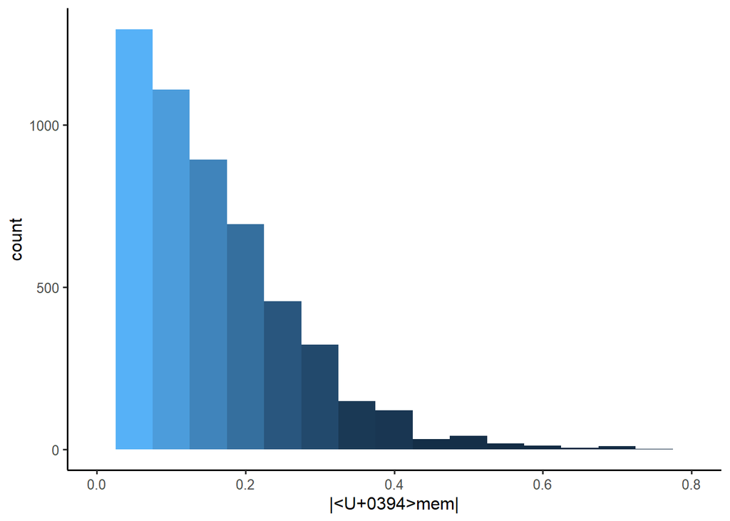

```r
#plot abs delta mem
g.deltaMem = choice %>% ggplot(aes(x = abs.mem, fill=..count..))+
  geom_histogram(binwidth = 0.05, show.legend = FALSE)+
  xlim(0,0.8)+
  xlab("|Δmem|")+
  theme_classic(base_size = 12)

g.deltaMem
```

### Variance of delta word memorability (Figure S2)

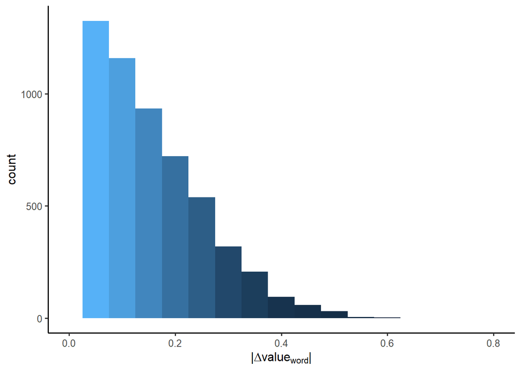

```r
## plot the abs delta mem for words
g.deltaMem_w = choice.test %>% ggplot(aes(x = abs.mem, fill=..count..))+
  geom_histogram(binwidth = 0.05, show.legend = FALSE)+
  xlim(0,0.8)+
  xlab(expression(paste("|",Delta*value[word], "|")))+
  theme_classic(base_size = 12)

g.deltaMem_w
```